# 社会調査法 - 3 データの種類とまとめ方

```r
#パッケージの読み込み
library(tidyverse) #様々な機能の統合パッケージ
library(magrittr) #コードを見やすくする
library(stargazer)
library(gtsummary)
```

## 3.1 データの種類

データはその性質に応じて分類が可能です。

| 種類 | 尺度 | 説明 | 例 |
| --- | --- | --- | --- |
| 質的変数 | 名義尺度 | 性質を分類するために使われる（男 = 0, 女 = 1，のように性質に数値を割り当てる）。数値に意味はない。 | 性別，学籍番号 |
| 質的変数 | 順序尺度 | 並び順に意味がある尺度。大小関係はあるが，計算はできない。 | 人気ランキング，成績（秀優良可不可） |
| 量的変数 | 間隔尺度 | 大小関係に加えて間隔にも意味がある。計算可能だが，比には意味がない（西暦1000年の2倍は西暦2000年，という計算に意味はある？） | 西暦・温度 |
| 量的変数 | 比例尺度 | 間隔に加えて比率にも意味がある。 | 身長・体重・価格・売上高・利益 |

- データがそれぞれどの種類の尺度なのかによってまとめ方や分析での使い方が変わります。
  - 例えば，名義尺度である学籍番号の平均値を計算することは意味がありません。

### 3.1.1 課題

以下のデータの各列はそれぞれどの尺度ですか。ただし

- `id`: 学籍番号
- `class`: クラス
- `gender`: 性別
- `test`: テストの点
- `hometown`: 出身地

```r
data3 <- read_csv("data3.csv")
data3
```

```
# A tibble: 30 × 5
      id class gender  test hometown
   <dbl> <dbl> <chr>  <dbl> <chr>
 1     1     1 男       100 京都
 2     2     1 女        20 京都
 3     3     1 女        60 大阪
 4     4     1 女        80 兵庫
 5     5     1 男        40 兵庫
 6     6     1 女        90 大阪
 7     7     1 男        30 大阪
 8     8     1 男        60 奈良
 9     9     1 男        90 島根
10    10     1 女        30 兵庫
# … with 20 more rows
```

### 3.1.2 Rが理解しているデータの種類

データの種類にはいくつかあるということでしたが，rにもそれに（完全にではないけれど）対応したデータの種類があります。

- numeric (`num`数値型)：数値データ
- character (`chr`文字列型)：文字データ
- factor (`fctr`因子型)：カテゴリデータ
- logical (`lgl`論理値型)：trueかfalseの2択データ

エクセルやcsvファイルを読み込んだとき，Rは自動でこれらのうちのどれかとして読み取ります。どの種類として読み込まれたかは，画面右上のEnvironmentタブにあるDataウインドウから確認可能です。また，単に`データ名`を実行するもしくは`str(データ名)`でも確認可能です

```r
str(data3)
```

```
spc_tbl_ [30 × 5] (S3: spec_tbl_df/tbl_df/tbl/data.frame)
 $ id      : num [1:30] 1 2 3 4 5 6 7 8 9 10 ...
 $ class   : num [1:30] 1 1 1 1 1 1 1 1 1 1 ...
 $ gender  : chr [1:30] "男" "女" "女" "女" ...
 $ test    : num [1:30] 100 20 60 80 40 90 30 60 90 30 ...
 $ hometown: chr [1:30] "京都" "京都" "大阪" "兵庫" ...
 - attr(*, "spec")=
  .. cols(
  ..   id = col_double(),
  ..   class = col_double(),
  ..   gender = col_character(),
  ..   test = col_double(),
  ..   hometown = col_character()
  .. )
 - attr(*, "problems")=<externalptr>
```

初期状態では，genderとhometownが`chr`（文字列），それ以外が`num`（数値）になっています。しかし，例えばidやclassは名義尺度であるべきです。

後で使うclassをカテゴリデータに変えてみます。使うコマンドは`as.factor(変えたい変数)`です。

```r
data3 %<>%
  mutate(class = as.factor(class))
```

2行目の`mutate(新しい変数名 = 指示)` は，新しい変数（列）を足すコマンドです。現在ある列名と同じものを指定すると上書きされます。今回は，classという数値変数をカテゴリ変数に変えたものを，元と同じclassという名前で作成（上書き）しています。

文字列については，分析の際には自動的にカテゴリ変数として扱われるので，特段の変更処理は必要ありません。

## 3.2 データを要約する

膨大なデータの特徴を捉えるためには，代表的な値を使うといい。ここからは基本的に比例尺度を想定しています。

$$X_i = X_1, X_2,...X_n$$
とします。

### 3.2.1 平均値

データに含まれる値をすべて足してデータの数で割った値。$\bar X$ とすると。

$$\bar X = (X_1 + X_2 + ... X_n )/n = \frac{1}{n} \Sigma_{i=1}^{n} X_i$$

```r
data3_1 <- c(100,90,80,70,60,40,10)
xbar = mean(data3_1)
xbar
```

```
[1] 64.28571
```

```r
#これは以下でも同じ
xbar2 = sum(data3_1) / length(data3_1)
xbar2
```

```
[1] 64.28571
```

### 3.2.2 中央値

データを順番に並べてちょうど真ん中の値。

```r
median(data3_1)
```

```
[1] 70
```

平均値と中央値はそれぞれデータの代表的な値ではありますが，必ずしも一致しません。例えば以下のようなデータがあったとします。

```r
x <- c(10, 10, 10, 10, 10, 10, 10, 20, 20, 30, 90, 100)
```

```r
mean(x)
```

```
[1] 27.5
```

```r
median(x)
```

```
[1] 10
```

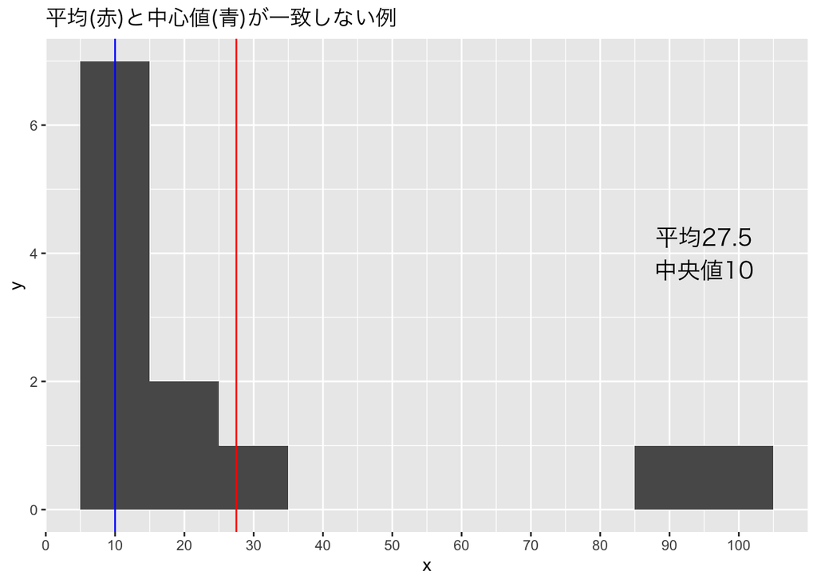

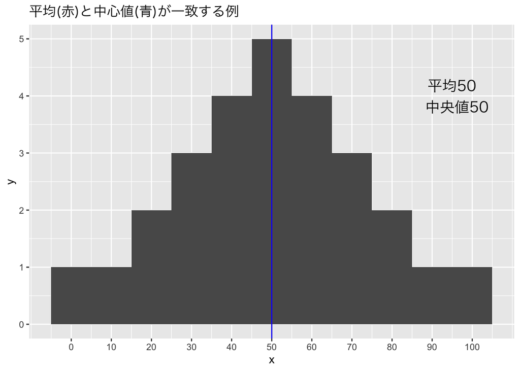

### 3.2.3 最大値・最小値

そのまま，最大の値と最小の値

```r
max(data3_1)
```

```
[1] 100
```

```r
min(data3_1)
```

```
[1] 10
```

---

### 3.2.4 分散

データのばらつき度合いを表します。例えば，A, Bという２つのクラスがあるとします。ある教科のテストの平均，中央値が両クラスとも60だったとしても，

1. 20,60,100,30,90
2. 60,60,60,60,60

というように特典の分布が全く異なる場合があり得ます。この違いは平均や中央値だけでは読み取れません。この違いを表す，平均からのばらつき度合いを把握する指標が分散です。

平均からの距離 （$\bar X - X_i$）は，プラスにもマイナスにもなり，足し合わせたら0になってしまうので，これを2乗した$(\bar X - X_i)^2$をデータの数だけ足し合わせて，データの数で割ったものを分散とします。

$$\text{分散} = \frac{1}{n} \Sigma_{i = 1}^n(\bar X - X_i)^2$$

```r
data3_2a <- c(20,60,100,30,90)
data3_2b <- c(60,60,60,60,60)

meana <- mean(data3_2a)
sa <- meana -　data3_2a
sua <- sum(sa^2)
分散a <- sua / length(data3_2a)

分散b = sum((mean(data3_2b) - data3_2b)^2)/length(data3_2b)

分散a
```

```
[1] 1000
```

```r
分散b
```

```
[1] 0
```

Aの分散は1000，Bの分散は0。

でも，この数値は何を意味しているのかがわからないです。なぜなら，元の点数（100点満点）を2乗しているからです。これをルートを取って元に戻すと，平均値とかと同じ単位になります。分散のルートを取ったものを標準偏差といいます。

$$\text{標準偏差} = \sqrt{\text{分散}}$$

```r
標準偏差A <- sqrt(分散a)
標準偏差A
```

```
[1] 31.62278
```

## 3.3 データの可視化

名義尺度など，計算が不可能なものを要約し，可視化する方法として，度数分布表とヒストグラムがあります。

### 3.3.1 度数分布表

名義尺度や順序尺度（もしくは範囲を区切った量的変数）ごとに当てはまるサンプルサイズを集計した表です。

```r
table(data3$hometown)
```

```
  京都   兵庫 北海道   大阪   奈良   島根   滋賀
     7      6      1     10      3      1      2
```

```r
data3 %>%
  select(.,hometown) %>%
  tbl_summary(.,
              label = list(hometown ~ ""),
              sort = list(everything() ~ "frequency")
              ) %>%
  modify_header(label = "")
```

|  | **N = 30**<sup>1</sup> |
| --- | --- |
| 大阪 | 10 (33%) |
| 京都 | 7 (23%) |
| 兵庫 | 6 (20%) |
| 奈良 | 3 (10%) |
| 滋賀 | 2 (6.7%) |
| 北海道 | 1 (3.3%) |
| 島根 | 1 (3.3%) |

<sup>1</sup> n (%)

### 3.3.2 ヒストグラム

特定のカテゴリごとの度数がわかるグラフです。例えばテストの点数なら，特定の範囲にどれぐらいの人がいるかがわかります。

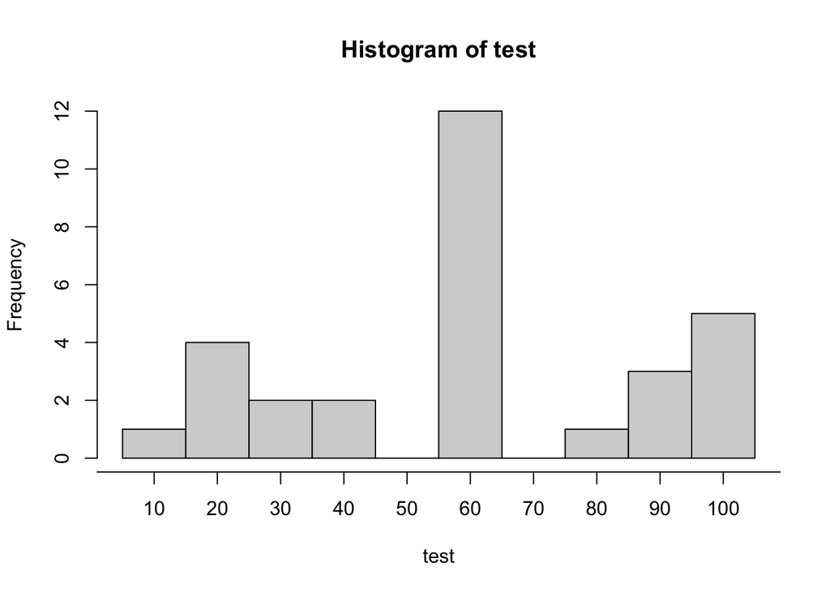

```r
data3 %$%
  hist(test,
       breaks = seq(5,105,10),　#10点ごとの幅に
       xaxt = "n"　#自動生成ラベルを非表示に
       )
axis(1, at = 10*(0:100))　#ラベルの指定（０から100まで10刻みに）
```

`ggplot2`というパッケージ(`tidyverse`に同梱)を使うと以下のように作成できます。この程度の単純な表だとggplotの方がややこしいですが，いろいろカスタマイズするにはこちらの方が良いらしいです。

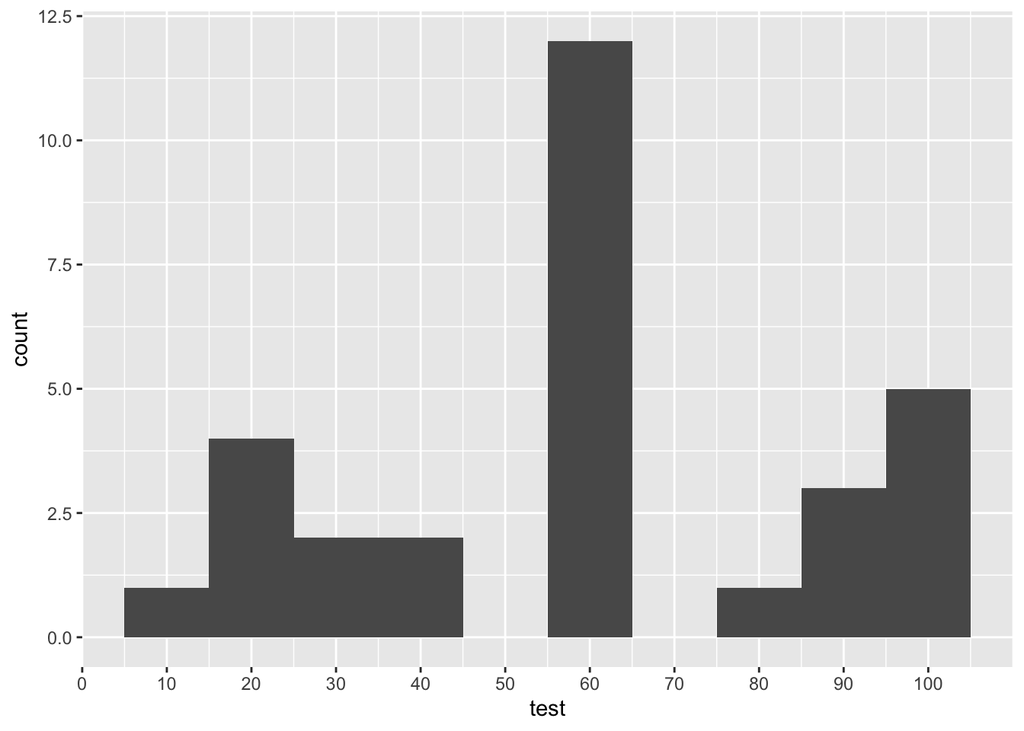

```r
data3 %$%
  ggplot(., aes(test)) + #x軸の基準を指定
  geom_histogram(breaks = seq(5,105,10)) + #ヒストグラムを作成（10点刻み）
  scale_x_continuous(breaks=seq(0,100,10))  #ラベルを作成(10点刻み)
```

例えば，グループごとに色分けする

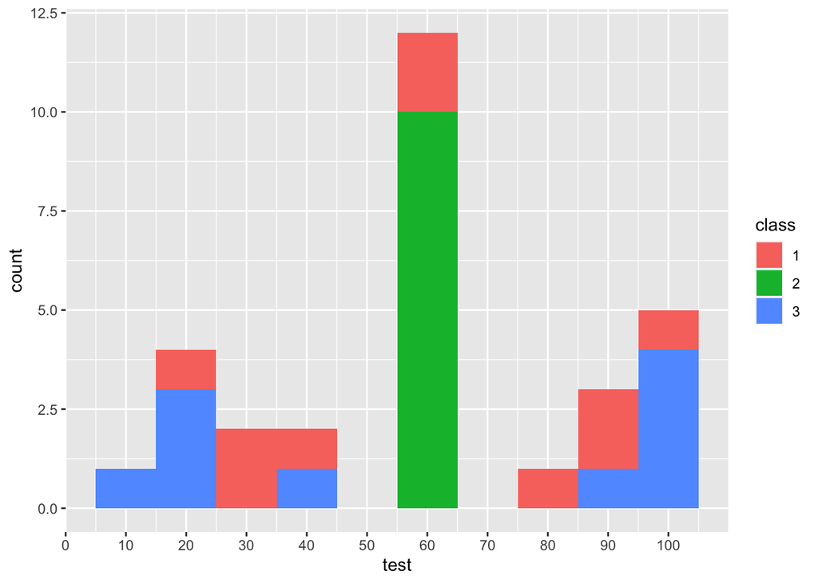

```r
data3 %>%
  ggplot(., aes(test, fill = class)) + #fillで色分けしたいグループを指定
  geom_histogram(breaks = seq(5,105,10)) +
  scale_x_continuous(breaks=seq(0,100,10))
```

クラスごとに分けて作成

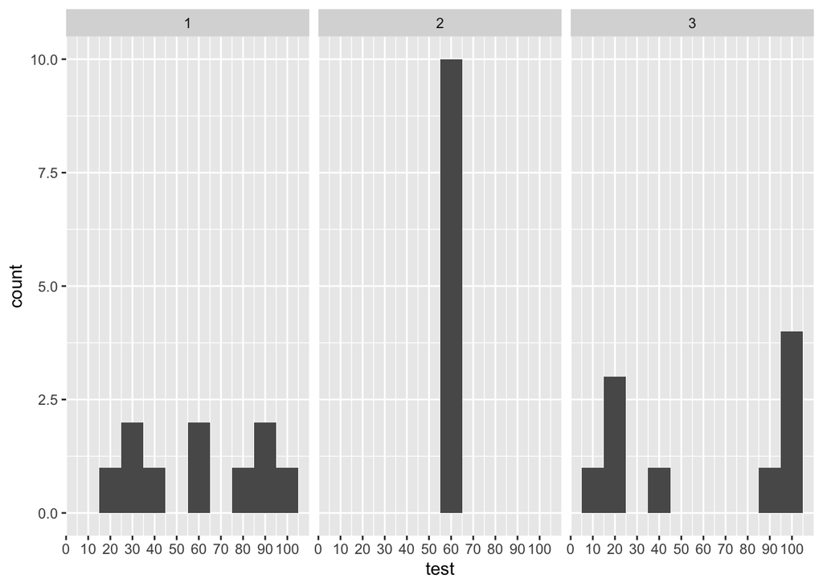

```r
data3 %$%
  ggplot(., aes(test)) +
  geom_histogram(breaks = seq(5,105,10)) +
  scale_x_continuous(breaks=seq(0,100,10)) +
  facet_grid(~class) #classごとに分けて表示
```

これだと，平均がどれも60点の3クラスだけど，特典のばらつき度合いが大きく違う，ということがわかりやすいです。

### 3.3.3 箱ひげ図

複数のグループごとの中央値やばらつき度合いを視覚的に表現できます。ここでは，クラスごとのテストの点数の箱ひげ図を書きます。

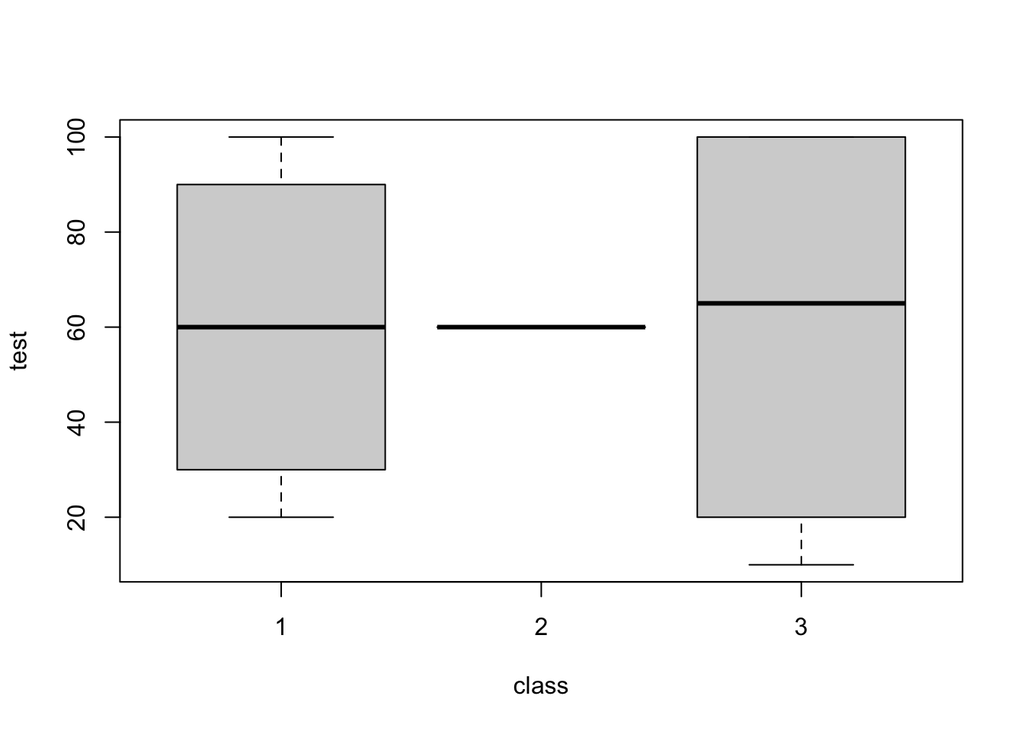

```r
data3 %$%
  boxplot(test~class)
```

- 最も外の線は最大値と最小値，箱の上下はそれぞれ75％点と25％点，つまり上下4分の1の点，真ん中の太線は中央値です。
- クラス2は全員が60点だったので，箱がなく中央値の線だけが記載されています（箱が潰れて線になっているイメージ）

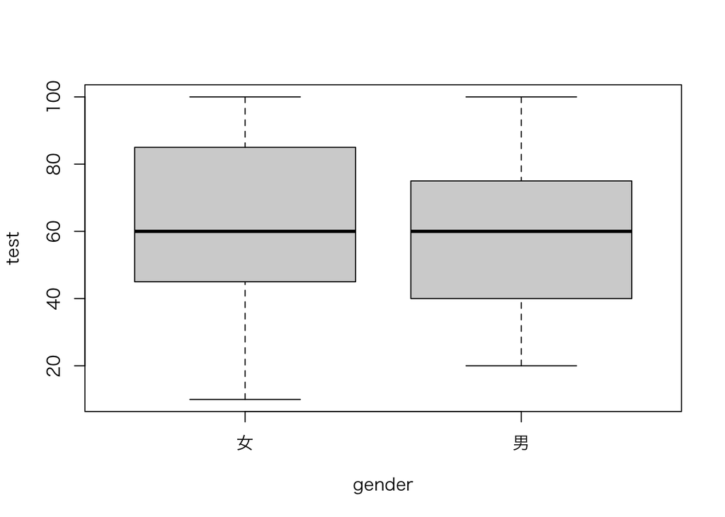

```r
par(family= "HiraKakuProN-W3")
data3 %$%
  boxplot(test~gender)
```